# Assignment 4

Fractional Factorial Design – Market Research Experiment

Rahul Sangole

Import libraries and setup the design using `pb()`. Also, overwritting the default factor names by the `factor.names` argument in `pb()` so that the dropped “I” factor name is brought back.

```r
library(FrF2)
library(DoE.base)
library(daewr)
library(dplyr)

design <-
    pb(
        nruns = 20,
        nfactors = 19,
        factor.names = LETTERS[1:19],
        randomize = FALSE
    )

y <-
    c(
        1.04,
        0.76,
        0.84,
        2.68,
        2.08,
        1.20,
        1.22,
        1.36,
        1.14,
        0.60,
        2.16,
        0.78,
        0.80,
        0.98,
        0.74,
        1.98,
        1.72,
        0.86,
        0.94,
        2.08
    )
design <- add.response(design , y)

design
```

```
##     A  B  C  D  E  F  G  H  I  J  K  L  M  N  O  P  Q  R  S    y
## 1   1  1 -1 -1  1  1  1  1 -1  1 -1  1 -1 -1 -1 -1  1  1 -1 1.04
## 2  -1  1  1 -1 -1  1  1  1  1 -1  1 -1  1 -1 -1 -1 -1  1  1 0.76
## 3   1 -1  1  1 -1 -1  1  1  1  1 -1  1 -1  1 -1 -1 -1 -1  1 0.84
## 4   1  1 -1  1  1 -1 -1  1  1  1  1 -1  1 -1  1 -1 -1 -1 -1 2.68
## 5  -1  1  1 -1  1  1 -1 -1  1  1  1  1 -1  1 -1  1 -1 -1 -1 2.08
## 6  -1 -1  1  1 -1  1  1 -1 -1  1  1  1  1 -1  1 -1  1 -1 -1 1.20
## 7  -1 -1 -1  1  1 -1  1  1 -1 -1  1  1  1  1 -1  1 -1  1 -1 1.22
## 8  -1 -1 -1 -1  1  1 -1  1  1 -1 -1  1  1  1  1 -1  1 -1  1 1.36
## 9   1 -1 -1 -1 -1  1  1 -1  1  1 -1 -1  1  1  1  1 -1  1 -1 1.14
## 10 -1  1 -1 -1 -1 -1  1  1 -1  1  1 -1 -1  1  1  1  1 -1  1 0.60
## 11  1 -1  1 -1 -1 -1 -1  1  1 -1  1  1 -1 -1  1  1  1  1 -1 2.16
## 12 -1  1 -1  1 -1 -1 -1 -1  1  1 -1  1  1 -1 -1  1  1  1  1 0.78
## 13  1 -1  1 -1  1 -1 -1 -1 -1  1  1 -1  1  1 -1 -1  1  1  1 0.80
## 14  1  1 -1  1 -1  1 -1 -1 -1 -1  1  1 -1  1  1 -1 -1  1  1 0.98
## 15  1  1  1 -1  1 -1  1 -1 -1 -1 -1  1  1 -1  1  1 -1 -1  1 0.74
## 16  1  1  1  1 -1  1 -1  1 -1 -1 -1 -1  1  1 -1  1  1 -1 -1 1.98
## 17 -1  1  1  1  1 -1  1 -1  1 -1 -1 -1 -1  1  1 -1  1  1 -1 1.72
## 18 -1 -1  1  1  1  1 -1  1 -1  1 -1 -1 -1 -1  1  1 -1  1  1 0.86
## 19  1 -1 -1  1  1  1  1 -1  1 -1  1 -1 -1 -1 -1  1  1 -1  1 0.94
## 20 -1 -1 -1 -1 -1 -1 -1 -1 -1 -1 -1 -1 -1 -1 -1 -1 -1 -1 -1 2.08
## class=design, type= pb
```

### 1. Verify that in this design each main effect is aliased with all 2-factor interactions except those that involve that main effect

I think this can be done visually using the `colormap()` function. Though, with the large number of factors and their 2-level interactions, it becomes very difficult to discern visually.

First, we can look at the colormap for this PB-20 design for just the first 5 factors. We can see:

- Factor A is partially correlated with BD BE etc
- Factor B is partially correlated with AD AE CE etc
- Factor C is partially correlated with BE etc …

Thus, each main effect is aliased with 2 factor interactions except those 2-factor interactions which contain the main effect.

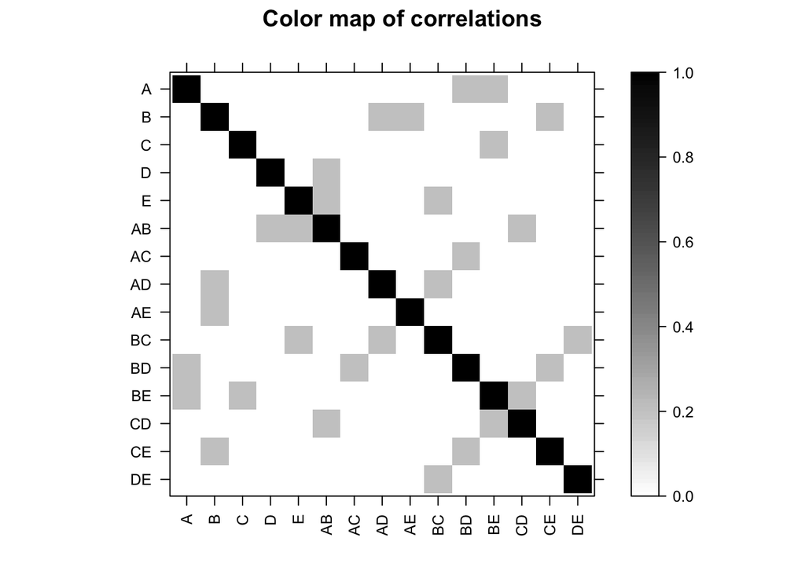

```r
colormap(design = design[,1:5],mod = 2)
```

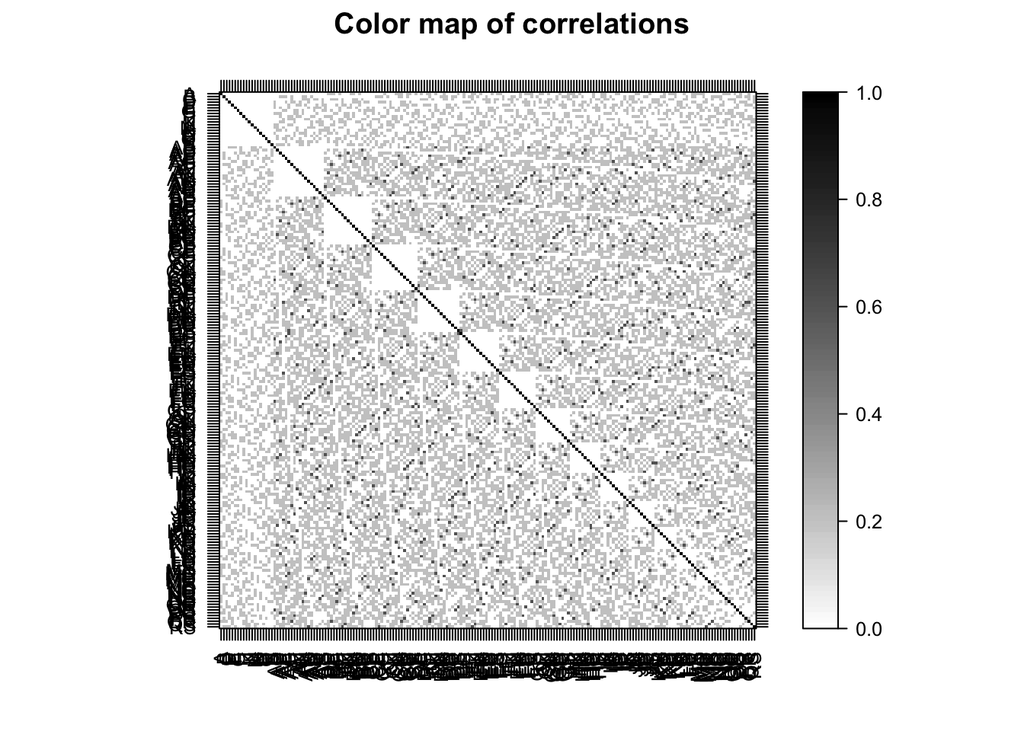

```r
colormap(design = design,mod = 2)
```

### 2. Verify that the five largest main effects are S, G, R, I, and J.

This can be done in two ways:

1. Look at the top 5 absolute values of the coefficients of a linear model:

```r
mod1 <- lm(y ~ (.) ^ 2, data = design)
sort(abs(coef(mod1)),decreasing = T)[2:6]
```

```
##    S1    G1    R1    I1    J1
## 0.432 0.278 0.152 0.148 0.096
```

2. Visually, we can plot a half-normal plot and arrive at the same conclusion:

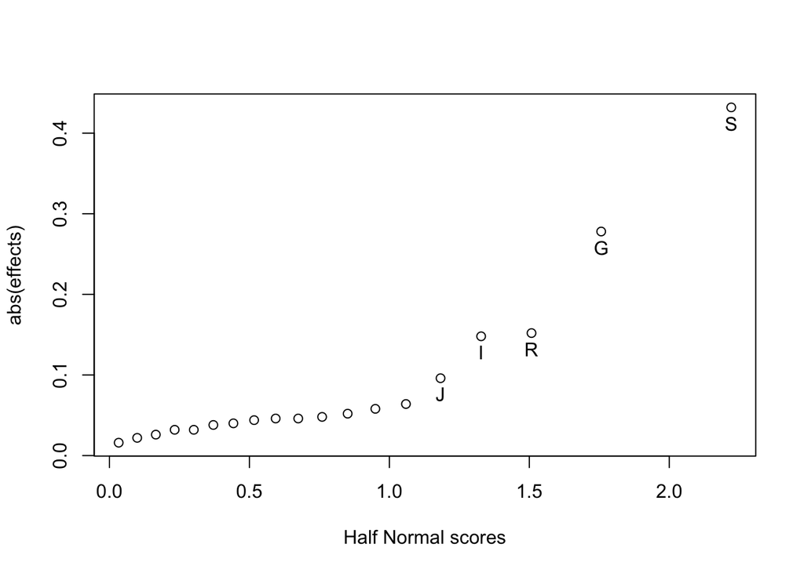

```
## zscore= 0.03298793 0.09910786 0.1656644 0.2329639 0.3013365 0.3711493 0.4428217 0.5168467 0.5938214 0.6744898 0.7598096 0.8510585 0.9500138 1.059277 1.182917 1.327902 1.507905 1.756827 2.22152effp= 0.016 0.022 0.026 0.032 0.032 0.038 0.04 0.044 0.046 0.046 0.048 0.052 0.058 0.064 0.096 0.148 0.15…
```

```r
cfs <- coef(mod1)[2:20]
names <- names(cfs)
halfnorm(cfs, names, alpha = .25, refline = FALSE)
```

### 4. Fit a full factorial model involving all 3 of these factors and the interactions. Show that S, G, and the SG interaction are significant.

First, select the 3 factors S, G, R and the response y.

```r
df <- tbl_df(design) %>%
    select(S,G,R,y)
print(df)
```

```
## # A tibble: 20 × 4
##         S      G      R     y
## *  <fctr> <fctr> <fctr> <dbl>
## 1      -1      1      1  1.04
## 2       1      1      1  0.76
## 3       1      1     -1  0.84
## 4      -1     -1     -1  2.68
## 5      -1     -1     -1  2.08
## 6      -1      1     -1  1.20
## 7      -1      1      1  1.22
## 8       1     -1     -1  1.36
## 9      -1      1      1  1.14
## 10      1      1     -1  0.60
## 11     -1     -1      1  2.16
## 12      1     -1      1  0.78
## 13      1     -1      1  0.80
## 14      1     -1      1  0.98
## 15      1      1     -1  0.74
## 16     -1     -1     -1  1.98
## 17     -1      1      1  1.72
## 18      1     -1      1  0.86
## 19      1      1     -1  0.94
## 20     -1     -1     -1  2.08
```

The first three columns contain a full factorial design in 3 factors, with a few of the runs repeated.

This can be confirmed using this code:

```r
df %>% select(-y) %>% unique %>% arrange(S,G,R)
```

```
## # A tibble: 8 × 3
##        S      G      R
##   <fctr> <fctr> <fctr>
## 1     -1     -1     -1
## 2     -1     -1      1
## 3     -1      1     -1
## 4     -1      1      1
## 5      1     -1     -1
## 6      1     -1      1
## 7      1      1     -1
## 8      1      1      1
```

Now, we fit a full factorial model to `df` including all 2 level interactions:

```r
df.lm <- lm(y~(.)^2,df)
summary(df.lm)
```

```
##
## Call:
## lm.default(formula = y ~ (.)^2, data = df)
##
## Residuals:
##     Min      1Q  Median      3Q     Max
## -0.2580 -0.1430 -0.0355  0.0720  0.4570
##
## Coefficients:
##             Estimate Std. Error t value Pr(>|t|)
## (Intercept)  1.29800    0.05171  25.100 2.13e-12 ***
## S1          -0.38625    0.06464  -5.975 4.63e-05 ***
## G1          -0.32000    0.06464  -4.950 0.000265 ***
## R1          -0.06125    0.06464  -0.948 0.360653
## S1:G1        0.15125    0.06464   2.340 0.035902 *
## S1:R1       -0.07000    0.06464  -1.083 0.298537
## G1:R1        0.07625    0.06464   1.180 0.259307
## ---
## Signif. codes:  0 '***' 0.001 '**' 0.01 '*' 0.05 '.' 0.1 ' ' 1
##
## Residual standard error: 0.2313 on 13 degrees of freedom
## Multiple R-squared:  0.8987, Adjusted R-squared:  0.852
## F-statistic: 19.23 on 6 and 13 DF,  p-value: 9.111e-06
```

We can also see that the main effect R is not significant (p=0.36>0.05).